# Pennsylvania Drug Overdose Dashboard

BSTA 374 · 15 points · Due Tuesday, November 17, 2026, 11:59 pm

Author

Aaron Colon · Lehigh University

## What M1 is

> **M1 — Static dashboard (15 pts).** A `flexdashboard` that loads your data and displays at least one map and one time series, deployed or renderable from your repository.

In the last lecture (*Your First Dashboard*) we built this dashboard on lung cancer in Ohio. M1 is the same file, on the dataset from your proposal. Nothing in it is new: the map is the `leaflet` map of Exercise 4, the time series an ordinary `ggplot`. The work is getting your data in, and telling the reader clearly what they are looking at.

Your dashboard has three panels:

| Panel | Answers | Part |
| --- | --- | --- |
| a map | *where* | B |
| a time series, or a funnel plot if your data have no time | *when*, or *how far to trust each area* | C |
| About these data | *what, from where, with which limits* | D |

Loading the data (A), the repository (E) and the AI use note (F) complete the 15 points.

**ImportantBefore you start**

1. Install the packages once, in the **Console**: `install.packages(c("flexdashboard", "plotly", "DT"))`.
2. Put your data in the `data/` folder of your course repository.
3. Copy the whole Ohio file (§3.5 of the lecture) into a new file, **`dashboard.Rmd`**, at the top of your repository, next to `data/`. **Knit it once with the Ohio data before you change anything.** If Ohio knits, your setup works, and any later error comes from your data.

**ImportantSubmission**

On Course Site, by **Tuesday, November 17, 2026, 11:59 pm**:

1. upload the knitted `dashboard.html`, renamed `LASTNAME_FI_M1.html`;
2. in the text box: the URL of your GitHub repository, the GitHub Pages address of your dashboard if you published it (optional), and your AI use note (Part F).

Late work follows the policy in the syllabus.

**TipNot every dataset looks like Ohio**

- **No expected counts:** map a rate instead (Part B).
- **Point data** (case, facility or crash locations): see *If your data are points*, after Part C.
- **No time component**, only if we agreed on it: a funnel plot replaces the time series (end of Part C).
- **Data not usable yet:** email me this week, not on November 16.

## Part A — Your data in the dashboard (3 points)

Change only the setup chunk; the layout stays. As in the lecture, the data are summarised twice: one row per area for the map, one row per period for the time series.

| In the Ohio file | For your data |
| --- | --- |
| `read_csv("data/ohio_lung_cancer_1968_1988.csv", ...)` | your file, with a relative path, `data/...`, never `C:/Users/...` |
| `col_types = cols(GEOID = "c")` | your ID column, as text |
| `counties(state = "OH", ...)` | your state; `tracts()` or `zctas()` for other units |
| `Y`, `E`, `year` | your counts, your expected counts or population, your time column |
| `focus <- "Cuyahoga"` | one area of your data (Part C) |

IDs read as numbers lose their leading zeros: Alabama’s Autauga County, `01001`, becomes `1001`, and the join fails without an error. Pad them back, as in Exercise 4:

```r
dat <- dat |>
  mutate(GEOID = sprintf("%05d", as.integer(GEOID)))     # counties: 5 digits
# tracts, 11 digits: stringr::str_pad(GEOID, 11, pad = "0")
```

Then run the join check of the lecture, with `rate` in place of `SIR` if you map a rate:

```
sum(is.na(my_map$SIR))                                   # should be 0
my_map$NAME[is.na(my_map$SIR)]                           # which areas, if not
```

If it is not 0, find out why: a failed join, which you fix, or suppressed counts, which you report in the About panel (Part D).

```r
library(tidyverse)
library(sf)
library(tigris)
library(lubridate)

# 1. Load dataset
raw <- read_csv(
  "data/VSRR_Provisional_County-Level_Drug_Overdose_Death_Counts_20261117.csv",
  col_types = cols(
    FIPS = col_character(),
    `Provisional Drug Overdose Deaths` = col_character(),
    .default = col_guess()
  )
)

# 2. Filter Pennsylvania and clean variables
dat <- raw |>
  filter(ST_ABBREV == "PA") |>
  transmute(
    GEOID = str_pad(FIPS, 5, pad = "0"),
    county = COUNTYNAME,
    month = mdy(MonthEndingDate),
    deaths = parse_number(
      `Provisional Drug Overdose Deaths`
    )
  )

# 3. One row per county for the map
# Use the latest 12-month ending period
latest_month <- max(dat$month)

by_area <- dat |>
  filter(month == latest_month) |>
  select(GEOID, county, cases = deaths)

# 4. One row per month for the time series
by_period <- dat |>
  group_by(month) |>
  summarise(
    cases = sum(deaths, na.rm = TRUE),
    n_missing = sum(is.na(deaths)),
    .groups = "drop"
  )

# 5. Pennsylvania county boundaries
pa_counties <- counties(
  state = "PA",
  cb = TRUE,
  year = 2020,
  progress_bar = FALSE
) |>
  st_transform(4326)

# 6. Join geographic and overdose data
my_map <- pa_counties |>
  left_join(by_area, by = "GEOID")

# 7. Choose focus county for Part C
focus <- "Philadelphia"

focus_series <- dat |>
  filter(county == focus)

# 8. Check missing values
sum(is.na(my_map$cases))
```

```
[1] 24
```

```r
my_map$NAME[is.na(my_map$cases)]
```

```
 [1] "Clearfield"  "Clarion"     "Huntingdon"  "Juniata"     "Pike"
 [6] "Wayne"       "Potter"      "Warren"      "Tioga"       "Jefferson"
[11] "Bedford"     "Fulton"      "Susquehanna" "Columbia"    "Sullivan"
[16] "Mifflin"     "Bradford"    "Elk"         "Montour"     "Adams"
[21] "Wyoming"     "Forest"      "Perry"       "McKean"
```

```r
# 9. Check unmatched geographic IDs
nrow(anti_join(
  st_drop_geometry(pa_counties),
  by_area,
  by = "GEOID"
))
```

```
[1] 0
```

We imported CDC provisional drug overdose death data and filtered it to Pennsylvania’s 67 counties. We cleaned the data by formatting FIPS codes, converting dates, and extracting overdose death counts. We created county-level (`by_area`) and monthly (`by_period`) summaries and joined the county data to Pennsylvania’s geographic boundaries using GEOID. All 67 counties were matched, but 24 counties had missing or suppressed death counts, which were retained as NA values rather than zero.

## Part B — The map (3.5 points)

One `leaflet` map of your measure, for all periods pooled or for the most recent period; the panel title says which.

**An SIR** keeps the Exercise 4 classes and the red–blue palette of the lecture, so that the neutral class sits around 1.

**A rate** has no neutral value, so it takes a sequential palette. Pooled over several years, divide the cases by the population **summed over the years** (person-years); the result is an average annual rate.

```r
by_area <- dat |>
  group_by(GEOID) |>
  summarise(cases = sum(cases), pop = sum(population), .groups = "drop") |>
  mutate(rate = 1e5 * cases / pop)                       # per 100,000 person-years

breaks <- quantile(by_area$rate, seq(0, 1, 0.2), na.rm = TRUE)   # quintiles
pal <- colorBin("YlOrRd", domain = by_area$rate, bins = unique(breaks))
```

Then `fillColor = ~pal(rate)` in `addPolygons()`, and `title = "Rate per 100,000"` in `addLegend()`. `colorBin()` with quintile breaks, rather than `colorQuantile()`, puts the rates themselves in the legend instead of percentiles.

**What earns the points:**

- the legend has a title with units;
- the panel title says what, where and when, e.g. *Lung cancer SIR by county, Ohio, 1968–1988*;
- the hover label gives the area’s name, its value **and the count behind it**, so that the reader can tell whether a dark colour rests on many cases or on a handful;
- a `>` note under the map says, in one sentence, what the colours mean.

```r
library(leaflet)
# Quintile breaks for county death counts
breaks <- unique(as.numeric(quantile(
  my_map$cases,
  probs = seq(0, 1, 0.2),
  na.rm = TRUE
)))

# Sequential yellow-to-red palette
pal <- colorBin(
  "YlOrRd",
  domain = my_map$cases,
  bins = breaks,
  na.color = "#D9D9D9",
  pretty = FALSE
)

# County hover labels
my_map <- my_map |>
  mutate(
    hover_text = if_else(
      is.na(cases),
      paste0(NAME, ": Count suppressed"),
      paste0(
        NAME, ": ",
        format(cases, big.mark = ",", trim = TRUE),
        " overdose deaths (12-month total)"
      )
    )
  )

# Create map
leaflet(my_map) |>
  addTiles() |>
  addPolygons(
    color = "white",
    weight = 1,
    fillColor = ~pal(cases),
    fillOpacity = 0.85,
    label = ~hover_text,
    highlightOptions = highlightOptions(
      color = "#333333",
      weight = 2,
      bringToFront = TRUE
    )
  ) |>
  addLegend(
    position = "bottomright",
    pal = pal,
    values = ~cases,
    title = "Drug overdose deaths (12-month count)",
    opacity = 0.85,
    na.label = "Suppressed"
  )
```

[interactive chart not shown]

Darker red counties represent higher reported numbers of drug overdose deaths, while lighter yellow counties represent lower counts. Gray counties represent suppressed data, meaning their overdose death counts were withheld to protect privacy or because the counts were too small to report reliably. These missing values do not indicate that zero overdose deaths occurred.

## Part C — The time series (3.5 points)

One line for the whole study area and one for the area you chose (`focus`), as in the lecture. With point data, one line of counts per period is enough.

If your periods are months or weeks, make the time column a `Date` (`as.Date()`, or `lubridate::ym()` for values such as `"2021-03"`), and `ggplot()` spaces the axis correctly.

**What earns the points:**

- the y-axis names the measure and its units (`labs(y = "Rate per 100,000")`);
- for an SIR, the dashed line at 1 stays;
- the `focus` area has enough cases to be readable: with a handful per year, its line jumps up and down and says little, the small-numbers problem of Exercise 4;
- a `>` note under the panel says, in one sentence, what the series shows: a rise, a fall, a peak, or no clear change.

`ggplotly(p)` (hover, zoom) is welcome but not required.

### If your data have no time component

Check first: many sources publish one release per year (CDC WONDER can group by year; County Health Rankings and CDC PLACES publish yearly releases). Three or four years are enough for a time series, and M2 and M3 build on one.

If your data really cover a single period, and we agreed on it, replace the time series with a **funnel plot**: each area’s value against its size. The map shows *where* values are high; the funnel plot shows *which of them rest on enough cases to take seriously*, the small-numbers problem of Exercise 4. By chance alone, the SIR of an area with $E$ expected cases varies by about $1/\sqrt{E}$, so the band of chance variation narrows as $E$ grows.

```r
d <- st_drop_geometry(my_map) |>
  filter(!is.na(SIR))                                    # areas with data

# 95% limits around SIR = 1 (normal approximation)
funnel <- tibble(E = 10^seq(log10(min(d$E)), log10(max(d$E)),
                            length.out = 100)) |>
  mutate(lo = pmax(0, 1 - 1.96 / sqrt(E)),
         hi = 1 + 1.96 / sqrt(E))

p <- ggplot(d, aes(E, SIR)) +
  geom_hline(yintercept = 1, colour = "grey50") +
  geom_line(data = funnel, aes(y = lo), linetype = 2) +
  geom_line(data = funnel, aes(y = hi), linetype = 2) +
  geom_point(aes(text = NAME), colour = "#B2182B") +     # text: hover label
  scale_x_log10() +
  labs(x = "Expected cases (log scale)", y = "SIR") +
  theme_minimal()

ggplotly(p, tooltip = c("text", "x", "y"))               # hover, zoom
```

With a rate, centre the funnel on the overall rate, with the population on the x-axis:

```r
d <- st_drop_geometry(my_map) |>
  filter(!is.na(rate))                                   # areas with data

r0 <- sum(d$cases) / sum(d$pop)                          # overall rate
funnel <- tibble(pop = 10^seq(log10(min(d$pop)), log10(max(d$pop)),
                              length.out = 100)) |>
  mutate(lo = 1e5 * pmax(0, r0 - 1.96 * sqrt(r0 / pop)),
         hi = 1e5 * (r0 + 1.96 * sqrt(r0 / pop)))
# then aes(pop, rate), yintercept = 1e5 * r0, x = "Population (log scale)"
```

The limits are approximate, and rough below about 10 expected cases. About one area in 20 falls outside 95% limits by chance alone, so a point outside the funnel is worth a second look, not yet a finding. With point data and no time, see *If your data are points*, below.

**What earns the points** for the funnel plot: labelled axes with units; the reference line and the 95% limits; hover labels with the area’s name; a `>` note saying which areas lie outside the funnel, and whether they are the darkest areas on the map.

## If your data are points

One row per event (a case, a facility, a crash) with its coordinates and, ideally, a date. The layout stays; Parts A to D change as follows.

**WarningPrivate locations**

If each point is a person, such as a case at a home address, the points stay on your laptop. Do not push them to GitHub: in GitHub Desktop, right-click the data file under **Changes** and choose **Ignore file**. Do not upload the knitted dashboard either, since it contains the coordinates: upload `dashboard.Rmd` only, and show me the dashboard on your laptop. Facilities, crashes and audits are not private and follow the usual rules.

**A. Read the points.** There are no boundaries to join: the coordinates become an `sf` object. The boundaries only outline the study area.

```r
raw <- read_csv("data/my_points.csv")
pts <- raw |>
  filter(!is.na(lon), !is.na(lat)) |>                    # rows with coordinates
  st_as_sf(coords = c("lon", "lat"), crs = 4326)         # longitude first
nrow(raw) - nrow(pts)                                    # rows dropped

area <- counties(state = "PA", cb = TRUE, year = 2020,
                 progress_bar = FALSE) |>
  filter(NAME %in% c("Lehigh", "Northampton")) |>        # your study area
  st_transform(4326)
```

Unlike SaTScan’s coordinates file in Exercise 6, `coords` takes **longitude first**. Swapped, Pennsylvania lands in Antarctica. Coordinates in metres or feet, such as a state plane, take that system’s EPSG code in `crs =`, followed by `st_transform(4326)`.

**B. The map.** Circles in place of polygons, with the study area outlined so that the reader sees where there are no points:

```r
leaflet(pts) |>
  addProviderTiles("CartoDB.Positron") |>
  addPolygons(data = area, fill = FALSE, color = "grey40", weight = 1) |>
  addCircleMarkers(radius = 4, stroke = FALSE, fillOpacity = 0.6,
                   color = "#B2182B", label = ~as.character(date))
```

The label describes the point (its date, its type), never a name or an address. With thousands of points, add `clusterOptions = markerClusterOptions()` to `addCircleMarkers()`; the numbered bubbles count nearby points and are not statistical clusters. Points coloured by a category (`colorFactor()`) need a legend.

A point map has no denominator. Dense points mostly mark where many people live, or where the facilities are, as with complete spatial randomness in Exercise 3: the `>` note under the map says so.

**C. The time series.** Counts per period, as bars:

```r
by_month <- pts |>
  st_drop_geometry() |>
  mutate(date = as.Date(date)) |>
  count(month = lubridate::floor_date(date, "month"))    # cases per month

p <- ggplot(by_month, aes(month, n)) +
  geom_col(fill = "#B2182B") +
  labs(x = NULL, y = "Cases per month") +
  theme_minimal()

ggplotly(p)                                              # hover, zoom
```

`floor_date()` also takes `"week"` or `"year"`. Bars rather than a line: a month without cases has no row, and a line would join across it. Without a population, a rise in counts may come from more people, more testing or better reporting rather than higher risk; the note under the panel says what the bars show, with that caution.

**No dates?** Replace the time series with a kernel density map of the points, as in Exercise 3:

```r
xy <- st_transform(pts, 5070)                            # metres
ggplot() +
  stat_density_2d_filled(data = as.data.frame(st_coordinates(xy)),
                         aes(X, Y), contour_var = "ndensity", alpha = 0.8) +
  geom_sf(data = st_transform(area, 5070), fill = NA, colour = "grey30") +
  labs(fill = "Relative density") +
  theme_void()
```

The bandwidth here follows a default rule; in M2, a slider can hand it to the reader. The note under the panel says where the density peaks, and whether that is more than where people live.

**D. About these data.** State that there is no population at risk, so the maps show counts, not risk; how the locations were obtained (GPS, geocoded addresses); and how many rows were dropped for missing coordinates.

**What earns the points** with point data: in B, the study area outlined, labels that identify no one, a legend if the points are coloured, a title with what, where and when, and the note on the missing denominator; in C, the y-axis as counts per period (or the density legend), and a note on what the panel shows.

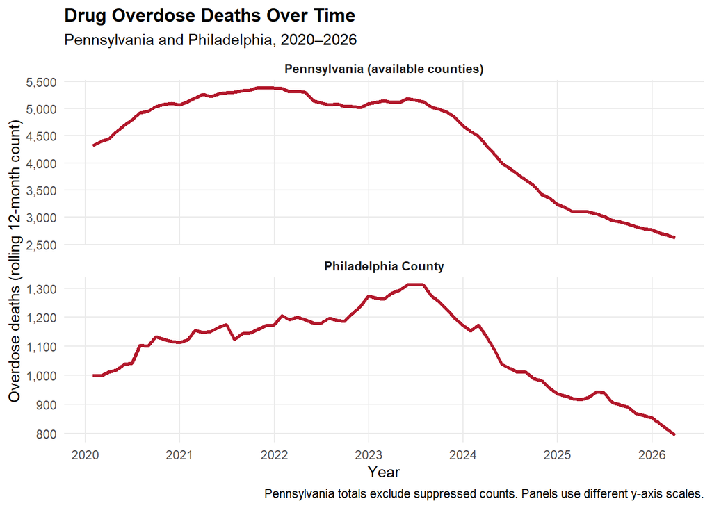

```r
library(ggplot2)
library(dplyr)

# Philadelphia time series
focus_data <- dat |>
  filter(county == focus) |>
  transmute(month, cases = deaths)

# Combine Pennsylvania and Philadelphia
series_data <- bind_rows(
  by_period |>
    transmute(
      month, cases,
      area = "Pennsylvania (available counties)"
    ),
  focus_data |>
    transmute(
      month, cases,
      area = paste0(focus, " County")
    )
)

# Create time series
p <- ggplot(
  series_data,
  aes(x = month, y = cases)
) +
  geom_line(
    color = "#B2182B",
    linewidth = 1.1
  ) +
  facet_wrap(
    ~area,
    ncol = 1,
    scales = "free_y"
  ) +
  scale_x_date(
    date_breaks = "1 year",
    date_labels = "%Y"
  ) +
  scale_y_continuous(
    labels = scales::label_comma()
  ) +
  labs(
    title = "Drug Overdose Deaths Over Time",
    subtitle = "Pennsylvania and Philadelphia, 2020–2026",
    x = "Year",
    y = "Overdose deaths (rolling 12-month count)",
    caption = paste(
      "Pennsylvania totals exclude suppressed counts.",
      "Panels use different y-axis scales."
    )
  ) +
  theme_minimal() +
  theme(
    strip.text = element_text(face = "bold"),
    plot.title = element_text(face = "bold"),
    panel.grid.minor = element_blank()
  )

p
```

We created a time series graph to examine changes in drug overdose deaths in Pennsylvania and Philadelphia County from 2020 to 2026. We used two separate graphs with different y-axis scales to make the trends easier to compare, since Pennsylvania has substantially more deaths than Philadelphia alone. The data represent rolling 12-month death counts.

The graphs show that overdose deaths initially increased in both areas before declining. Pennsylvania reached its highest levels around 2022, while Philadelphia peaked around mid-2023. After these peaks, both areas experienced substantial decreases through early 2026. This suggests an overall improvement in overdose mortality trends, although the data do not establish what caused the decline. Additionally, statewide totals exclude suppressed county counts, meaning the reported totals may underestimate the actual number of deaths.

## Part D — About these data (2 points)

A third panel, in plain text, with no R code. Most of it comes from your dataset proposal. For Ohio:

```markdown
### About these data

- **Outcome:** lung cancer cases, 1968--1988, by year.
- **Population at risk:** residents of Ohio's 88 counties.
- **Expected counts:** indirect standardization by age and sex.
- **Source:** Moraga (2019), Ch. 7; boundaries from the US Census Bureau, via `tigris`.
- **Areas without data:** none.
- **Limitation:** the expected counts use one set of rates for the whole
  period, so the map averages over the rise in lung cancer.
```

Put it in the second column, under the time series, in place of the table. To keep the table as well, give the About panel a third column of its own, with one more line `Column {data-width=300}` followed by a line of dashes.

**What earns the points:** the outcome and period; the population at risk and the geography (unit and number of areas); how the expected counts or the rate were computed; the source, with a link if there is one; the areas without data (Part A); and **one limitation** of your data, such as suppressed small counts, missing years or boundary changes. Your final dashboard has to state these limits in the app itself, so this panel carries over.

### About These Data

- **Outcome:** Provisional drug overdose death counts from January 2020 through March 2026, reported as rolling 12-month totals.
- **Population at risk:** Residents of Pennsylvania’s 67 counties.
- **Geography:** All 67 Pennsylvania counties, using county-level FIPS codes and geographic boundaries from the U.S. Census Bureau.
- **Method:** County-level overdose death counts were used for the map, while monthly rolling 12-month counts were used to examine trends over time. Available county counts were summed for the Pennsylvania time series. No population-adjusted rates or expected counts were calculated.
- **Source:** Centers for Disease Control and Prevention (CDC), National Center for Health Statistics, [VSRR Provisional County-Level Drug Overdose Death Counts](https://data.cdc.gov/d/gb4e-yj24). Geographic boundaries were obtained through the `tigris` R package.
- **Areas without data:** Of the 67 counties, 24 had suppressed death counts in the most recent period because of CDC confidentiality requirements. These were retained as missing values rather than zeros.
- **Limitations:** The data are provisional and may change as additional deaths are reported or investigated. Suppressed counts result in incomplete statewide totals. Additionally, raw death counts do not account for population differences between counties, limiting direct comparisons of overdose mortality risk.

## Part E — Renderable from your repository (2 points)

1. The YAML header keeps `source_code: embed`: I read your code from the **Source Code** button of the dashboard.
2. **Session > Restart R**, then **Knit**. Not `quarto render`, which turns the dashboard into a scrolling page. It must knit from a clean start.
3. Commit and push `dashboard.Rmd` **and your data** with GitHub Desktop. If your data cannot go on GitHub (a file over 50 MB, or data you may not share), push a script that downloads them, or email me how to obtain them.

**Publishing to GitHub Pages is optional** and earns the same credit (§3.7 of the lecture: two entries in `_quarto.yml`). It is worth doing: the Shiny version you build for M2 cannot run on GitHub Pages, so this is the version of your dashboard that others can open.

If Knit fails on your laptop, use a lab machine or [Posit Cloud](https://posit.cloud). If it fails everywhere, push the file anyway and email me the exact error message: partial work earns partial credit. The tables *Before you demonstrate M1* and *When it breaks* at the end of the lecture cover most problems.

## Part F — AI use note (1 point)

Two or three sentences in the text box of your submission: **which** tools you used, **what** for, and at **which stage** (planning, coding, debugging, interpreting, writing). No amount of disclosed use costs points.

ChatGPT was used to assist with coding, debugging, and interpreting results throughout the development of my dashboard. Specifically, AI helped with cleaning and organizing the CDC overdose dataset, creating the choropleth map and time series, and explaining data suppression and limitations. I reviewed the generated code and visualizations to ensure they accurately represented the data.

## Points

| Part | What earns the points | Points |
| --- | --- | --- |
| A | Data read with a relative path; ID kept as text; join check at 0, or the missing areas explained; one summary per area and one per period | 3 |
| B | Map of your measure with a palette suited to it; legend with title and units; panel title with what, where and when; hover label with name, value and count; note on the colours | 3.5 |
| C | Study area and one chosen area over time; y-axis with units; reference line at 1 for an SIR; readable `focus` area; note on what the series shows. Without time: funnel plot with its limits, hover labe… | 3.5 |
| D | Outcome, population, geography, method, source, areas without data, one limitation | 2 |
| E | `dashboard.Rmd` and data (or a download script) pushed; knits from a clean session; `source_code: embed` | 2 |
| F | AI use note | 1 |
|  | **Total** | **15** |

With point data, Parts B and C are graded on the criteria in *If your data are points*.

A reader who has never seen your data should understand each panel without asking you. Clear titles and notes earn as many points as the code.

**NoteNext: M2**

The Shiny lecture starts from this file. Keep `dashboard.Rmd` as your M1, and build M2 in a copy, `dashboard_app.Rmd`, so that adding `runtime: shiny` does not break what you submit here.